# Assignment 1

Patricia Angela Alvero Sibal

2025-09-27

# Description

This document contains my answers for assignment 1 specifically Tasks 1 and 4-8.

### Task 1 - Literature

2. Answer the following questions
1. What is the medically relevant insight from the article? Most methods to elucidate the function of lncRNA are limited in scope since they rely on a CRISPR-based knockdown system followed by a single cellular phenotypic assay. CRISPR-based knocked out assays could also affect the transcription machinery at the divergent promoter, potentially inducing off-target effects. Moreover, relying on a single cellular phenotypic assay fails to capture the full spectrum of the lncRNA’s functions along with the molecular pathways regulated by the lncRNA. The current study offers a more comprehensive high-throughput method of evaluating the function of numerous lncRNAs. By utilizing transcriptomic profiling through CAGE sequencing, the study’s approach gives insights on which molecular pathways, gene expressions, and cellular phenotype are affected by the lncRNA beyond what is observable in a single assay. Moreover, this study utilizes antisense oligonucleotides to knockdown lncRNA which has a limited effect on the chromatin structure, allowing a more accurate analysis of lncRNA functions. The method described in this study facilitates a potentially much quicker and comprehensive method in determining which lncRNAs contribute to disease progression not just in cancer but also in other diseases.
2. Which genomics technology/ technologies were used?
- Next Generation Sequencing via RNA sequencing and CAGE sequencing
- Chromosome conformation capture
- designing of antisense oligonucleotides
3. List and explain at least three questions/ hypotheses you can think of that extend the analysis presented in the paper.
1. Can the high knockdown efficiency of ASOs targeting lncRNA be observed when using a different cell line such as cancer cell lines or immune cells?
- it would be very interesting to explore whether the system that the authors developed could also be applied to other types of cells. This could pave the way to identifying lncRNAs linked to T cell exhaustion or MHC Class I downregulation in cancer cells.
2. Do lncRNAs that produce overlapping phenotypic effects share common structural motifs or are they regulated by the same transcription factors?
- if a common motif and TF could be found, it could offer insights on how to target therapeutically relevant lncRNAs.
3. Do isoforms of the same lncRNA induce the same effect?
- lncRNAs have several isoforms. Determining which specific isoform is responsible for the effect allows for the development of a more precise therapeutic strategy.

### Task 4 - R basic operations

1. What is the square root of 10?

```r
sqrt(10)
```

```
## [1] 3.162278
```

2. What is the logarithm of 32 to the base 2?

```r
log2(32)
```

```
## [1] 5
```

3. What is the sum of the numbers from 1 to 1000?

```r
sum(1:1000)
```

```
## [1] 500500
```

4. What is the sum of all even numbers from 2 to 1000?

```r
#seq with by = 2 lists every other number from 2 to 1000 thereby listing only even numbers
sum(seq(2, 1000, by = 2))
```

```
## [1] 250500
```

5. How many pairwise comparisons are there for 100 genes?

```r
#combination instead of permutation since order doesnt matter for pairwise comparisons
#choose(n,k) where n is the number of genes and k is 2 since we want pairwise comparisons
choose(100, 2)
```

```
## [1] 4950
```

6. And how many ways to arrange 100 genes in triples?

```r
#arrange means permutations, a function part of library(gtools)
#permutations(n,k) where n is the number of genes and k is 3 since we want triples
#permutations(n,k) generates a matrix with all the possible arrangement
#nrow counts the number of rows of the matrix which corresponds to the number of arrangements
nrow(permutations(100, 3))
```

```
## [1] 970200
```

### Task 5 - Using R example datasets

2. Describe briefly the content of the CO2 dataset using the help function.

```r
?CO2
```

```
## starting httpd help server ... done
```

```r
#The CO2 uptake of grass plants from Quebec and Mississippi was measured at several levels of ambient CO2 concentration.
```

3. What is the average and median CO2 uptake of the plants from Quebec and Mississippi?

```r
head(CO2)  #see overview of CO2 data set
```

```
##   Plant   Type  Treatment conc uptake
## 1   Qn1 Quebec nonchilled   95   16.0
## 2   Qn1 Quebec nonchilled  175   30.4
## 3   Qn1 Quebec nonchilled  250   34.8
## 4   Qn1 Quebec nonchilled  350   37.2
## 5   Qn1 Quebec nonchilled  500   35.3
## 6   Qn1 Quebec nonchilled  675   39.2
```

```r
mean(CO2$uptake[CO2$Type == "Mississippi"]) #choose rows of Mississippi plants only then calculate average of CO2 uptake
```

```
## [1] 20.88333
```

```r
median(CO2$uptake[CO2$Type == "Mississippi"])  #choose rows Mississippi plants only then calculate median of CO2 uptake
```

```
## [1] 19.3
```

```r
mean(CO2$uptake[CO2$Type == "Quebec"]) #choose rows of Quebec plants only then calculate average of CO2 uptake
```

```
## [1] 33.54286
```

```r
median(CO2$uptake[CO2$Type == "Quebec"]) #choose rows Quebec plants only then calculate median of CO2 uptake
```

```
## [1] 37.15
```

4. In the “airway” example data from Bioconductor, how many genes are expressed in each sample? How many genes are not expressed in any sample?

```r
data(airway)
head(airway) #assay(airway) contains the count table, rows are genes, columns are samples
```

```
## class: RangedSummarizedExperiment
## dim: 6 8
## metadata(1): ''
## assays(1): counts
## rownames(6): ENSG00000000003 ENSG00000000005 ... ENSG00000000460
##   ENSG00000000938
## rowData names(10): gene_id gene_name ... seq_coord_system symbol
## colnames(8): SRR1039508 SRR1039509 ... SRR1039520 SRR1039521
## colData names(9): SampleName cell ... Sample BioSample
```

```r
cat("Genes expressed in each sample:", colSums(assay(airway)!= 0))#count the number of non-zero entries per column
```

```
## Genes expressed in each sample: 24633 24527 25699 23124 25508 25998 24662 23991
```

```r
#(assay(airway)) == 0) returns TRUE (1) if gene count is 0
#rowSums((assay(airway)) == 0)>0 returns TRUE (1) if gene count (row) is 0 in at least 1 sample (column)
#sum(rowSums((assay(airway)) == 0)>0)  counts how many is TRUE
cat("Genes not expressed in any sample:", sum(rowSums((assay(airway)) == 0)>0))
```

[output not shown]

### Task 6 - R Functions

1. Write a function that calculates the ratio of the mean and the median of a given vector.

```r
outlier_check <- function(vector_name){
  mean(vector_name)/median(vector_name)
}
```

2. Write a function that ignores the lowest and the highest value from a given vector and calculate the mean.

```r
mean_trimmed <- function(vector_name){
  sorted_vector <- sort(vector_name, decreasing = TRUE)
  trimmed_vector <- sorted_vector[2:(length(sorted_vector) - 1)]
  mean(trimmed_vector)
}
```

3. Write a short (max. 300 characters, no spaces) explanation of why, how, and when not to use pipes.

Pipes are used to make a chain of operations on the same dataset more concise and readable. Doing so avoids the use of unneccessary intermediate variables. To use pipes, use %>% to pass data from one step to the next. Pipes cannot be used if an assignment is needed mid-sequence or if there is no suitable function that readily performs your next chain of commands.

4. Write a short explanation (max. 300 characters, no spaces) of why the apply-family of functions (apply, lapply, sapply etc.) could be useful.

they are useful because it makes it possible for one function to be applied to either all the rows or columns of a matrix and even to each element in a list or vector. This is very convenient since it avoids manual subsetting and iteration for each element prior to using the function.

### Task 7 - Basic visualization with R

1. Compare the distributions of the body heights of the two species from the ‘magic_guys.csv’ dataset graphically
1. using the basic ‘hist’ function as well as ‘ggplot’ and ‘geom_histogram’ functions from the ggplot2 package. Optimize the plots for example by trying several different ‘breaks’.

```r
mycsv <- file.choose() #get data address
magic_guys <- read.csv(mycsv)

#understand the data
View(magic_guys)
summary(magic_guys)
```

```
##     uniqId            species              length          weight
##  Length:100         Length:100         Min.   : 60.1   Min.   :35.20
##  Class :character   Class :character   1st Qu.:111.3   1st Qu.:48.33
##  Mode  :character   Mode  :character   Median :138.4   Median :58.65
##                                        Mean   :147.8   Mean   :59.94
##                                        3rd Qu.:178.7   3rd Qu.:72.03
##                                        Max.   :272.9   Max.   :82.80
```

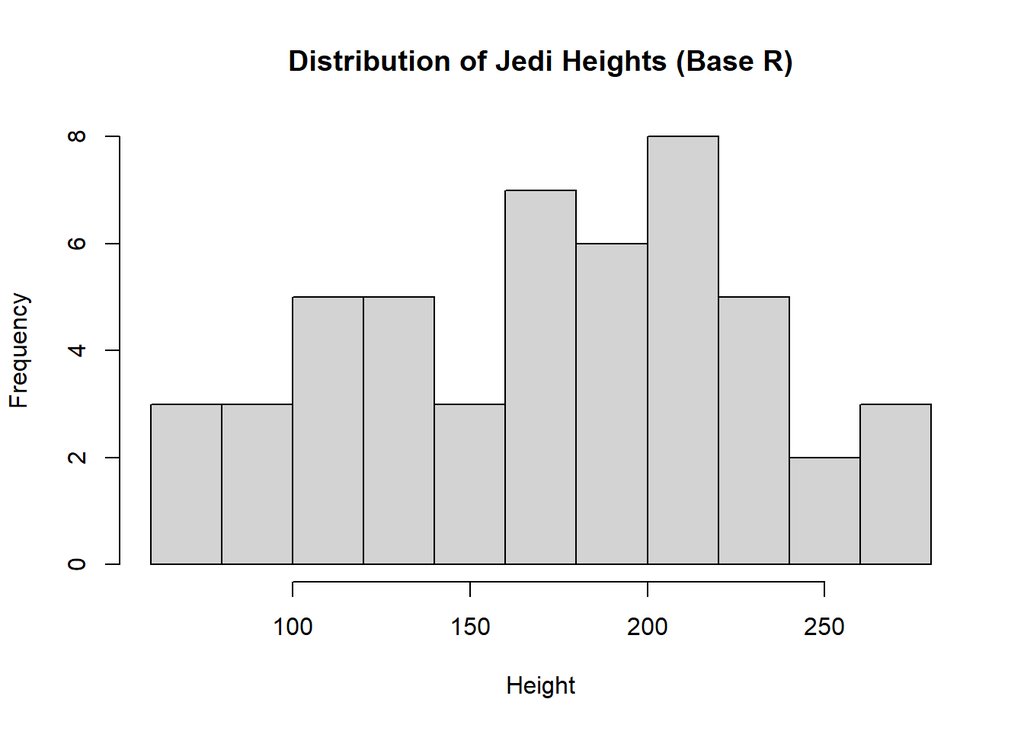

```r
hist(magic_guys$length[magic_guys$species == "jedi"], #choose only jedi heights
     breaks = 8,
     xlab = "Height", # x axis label
     main = "Distribution of Jedi Heights (Base R)") #title of the graph
```

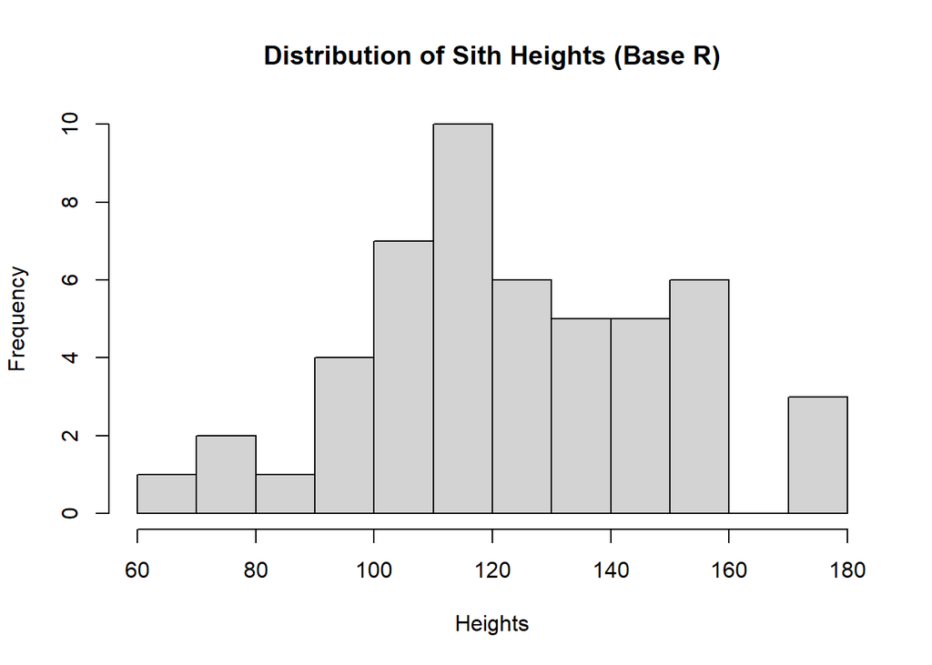

```r
hist(magic_guys$length[magic_guys$species == "sith"], #choose only sith heights
     breaks = 8,
     xlab = "Heights",
     main = "Distribution of Sith Heights (Base R)")
```

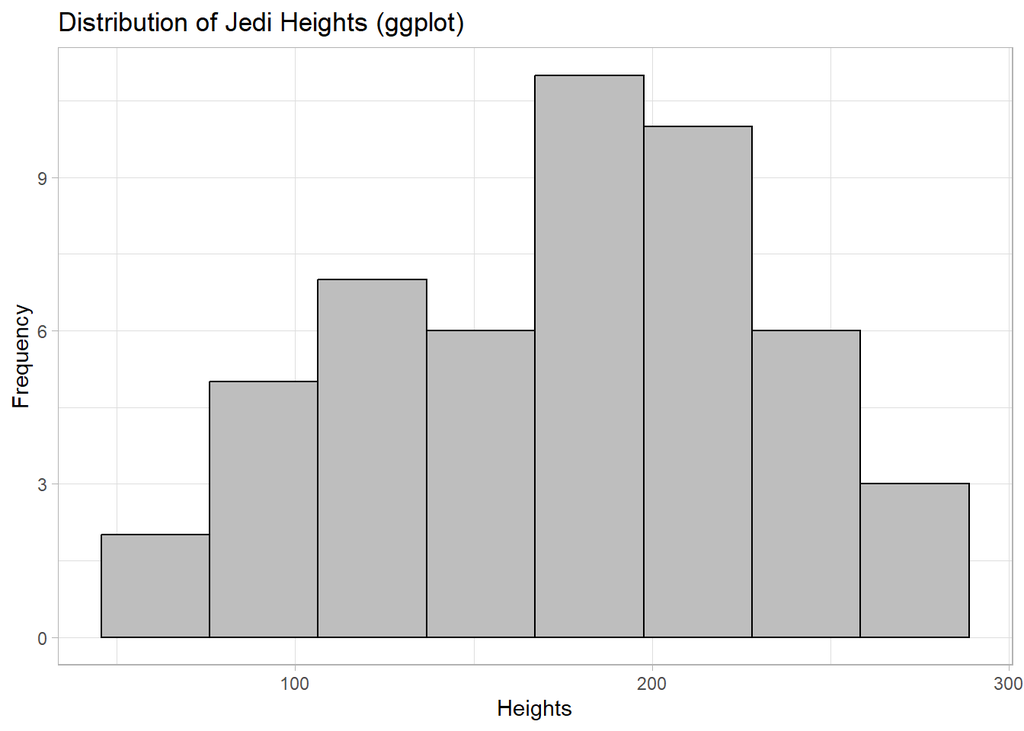

```r
#ggplot needs a dataframe so choose jedi rows, keep all columns then
#choose the column length for plotting through aes(x =)
gghist_jedi <- ggplot(magic_guys[magic_guys$species == "jedi", ], (aes(x=length))) +
  geom_histogram(bins = 8, fill = "grey", color = "black") + #fill is the color inside each bin while color is the outline
  theme_light() +  #color of the graph background
  labs(x = "Heights", y = "Frequency")+ #axis labels
  ggtitle("Distribution of Jedi Heights (ggplot)")

gghist_jedi
```

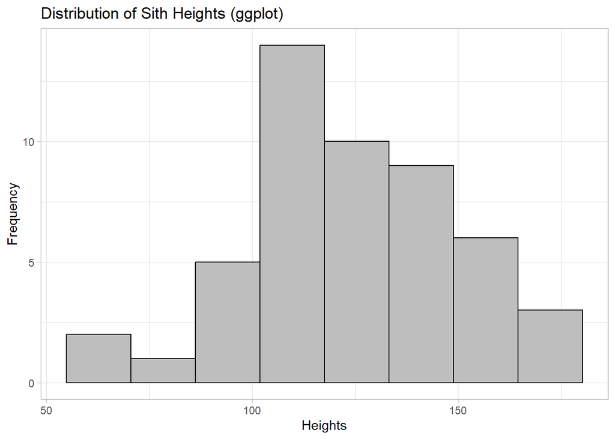

```r
gghist_sith <- ggplot(magic_guys[magic_guys$species == "sith", ], (aes(x=length))) +
  geom_histogram(bins = 8, fill = "grey", color = "black") +
  theme_light()+
  labs(x = "Heights", y = "Frequency")+
  ggtitle("Distribution of Sith Heights (ggplot)")

gghist_sith
```

```r
#small number of breaks/bins fail to accurately display distribution and pinpoint which range of heights are most abundant
#simplest way to calculate number of breaks/bins is by Sturge's formula: ceiling(log2(length(magic_guys$length)) + 1)
```

2. Do the same comparison as in a. but with boxplots.

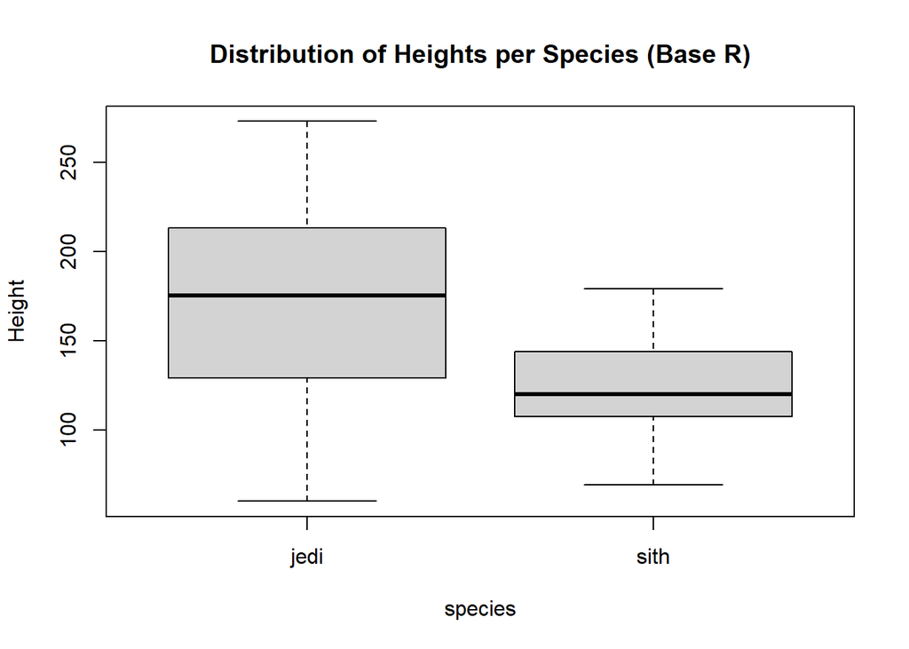

```r
#2 boxplots side by side showing height distribution per species
boxplot(length ~ species, data = magic_guys,
     ylab = "Height",
     main = "Distribution of Heights per Species (Base R)")
```

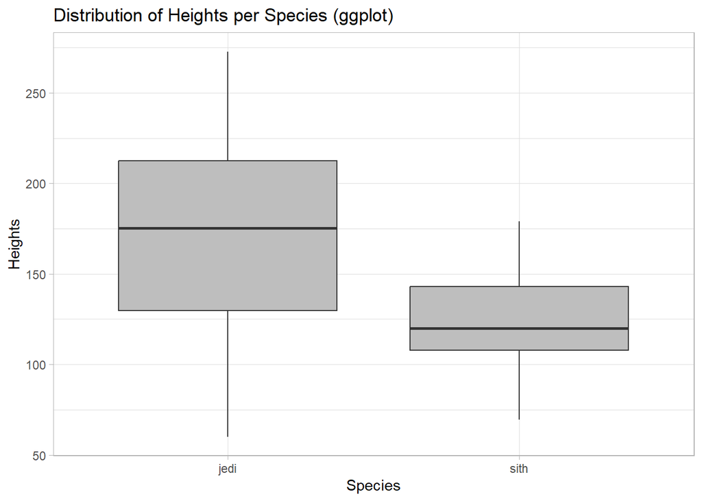

```r
#2 boxplots side by side showing height distribution per species
ggbox <- ggplot(magic_guys, (aes(x = species, y = length))) +
  geom_boxplot(fill = "grey") + #color of the boxes
  theme_light()+
  labs(x = "Species", y = "Heights")+
  ggtitle("Distribution of Heights per Species (ggplot)")

ggbox #display the boxplot
```

```r
#boxplots makes it easier to compare the distribution in one glance than histograms but
#does not offer much information on skewness and gaps
```

3. Save the plots with the ‘png’, ‘pdf’, and ‘svg’ formats. In which situation would you use which file format?

```r
out_dir <- "D:/RIKEN bioinformatics/RIKEN_KI_Bioinformatics_Course/plots" #define where the plots will be saved
if (!dir.exists(out_dir)) dir.create(out_dir, recursive = TRUE) #if the folder doesn't exist, create the folder

save_baseR <- function(code, name){

  #save as PNG
  png(file.path(out_dir, paste0(name,".png")), width = 800, height = 600)
  eval(substitute(code)) #evaluates the code for making the plot
  dev.off()

  #save as PDF
  pdf(file.path(out_dir, paste0(name,".pdf")), width = 8, height = 10 )
  eval(substitute(code))
  dev.off()

  #save as SVG
  svg(file.path(out_dir, paste0(name,".svg")), width = 8, height = 10)
  eval(substitute(code))
  dev.off()

}

save_ggplots <- function(code, name){

  #save as PNG
  ggsave(file.path(out_dir, paste0(name,".png")), code, width = 8, height = 10)

  #save as PDF
  ggsave(file.path(out_dir, paste0(name,".pdf")), code, width = 8, height = 10)

  #save as SVG
  ggsave(file.path(out_dir, paste0(name,".pdf")), code, width = 8, height = 10)

}

#save baseR histogram of sith
save_baseR(
  hist(magic_guys$length[magic_guys$species == "jedi"],
     breaks = 8,
     xlab = "Height",
     main = "Distribution of Jedi Heights (Base R)"),
  "jedi_histogram_baseR"
)
```

```r
#save baseR histogram of jedi
save_baseR(
  hist(magic_guys$length[magic_guys$species == "sith"],
     breaks = 8,
     xlab = "Heights",
     main = "Distribution of Sith Heights (Base R)"),
  "sith_histogram_baseR"
)
```

```r
#save baseR boxplots
save_baseR(
boxplot(length ~ species, data = magic_guys,
     ylab = "Height",
     main = "Distribution of Heights per Species (Base R)"),
  "boxplots_baseR"
)
```

```r
#save ggplot histogram of jedi
save_ggplots(gghist_jedi, "jedi_histogram_ggplot")

#save ggplot histogram of sith
save_ggplots(gghist_sith, "sith_histogram_ggplot")

#save ggplot boxplot
save_ggplots(ggbox, "boxplots_ggplot")
```

- svg: for a scalable image that maintains high quality and readily editable
- png: for quick preview, gets pixelated when scaled up
- pdf: typically used for publication as quality is high and layout + fonts are preserved in different platforms, not easily editable

2.Load the gene expression data matrix from the ‘microarray_data.tab’ dataset

1. How big is the matrix in terms of rows and columns?

```r
microarray_file <- file.choose()
microarray_data <- read.table(microarray_file, header = TRUE, sep = "\t")
dim(microarray_data) #gives the number of rows and columns, rows first then columns
```

```
## [1]  553 1000
```

2. Count the missing values per gene and visualize this result.

```r
View(microarray_data) #genes are in the columns

#count how many NAs per column
NA_table <- as.data.frame(colSums(is.na(microarray_data)))
colnames(NA_table) <- "NA_amount"
head(NA_table)
```

```
##    NA_amount
## g1       130
## g2       104
## g3        74
## g4        93
## g5        81
## g6        30
```

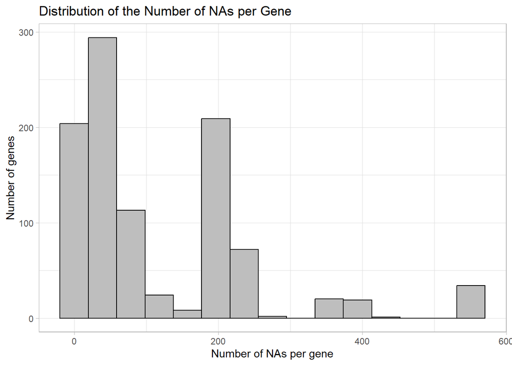

```r
#plot
ggplot(NA_table, (aes(x=NA_amount))) +
  geom_histogram(bins = 15, fill = "grey", color = "black") +
  theme_light() +
  labs(x = "Number of NAs per gene", y="Number of genes")+
  ggtitle("Distribution of the Number of NAs per Gene")
```

3. Find the genes for which there are more than X% (X=10%, 20%, 50%) missing values.

```r
  NA_genes_list <- function(X){
  threshold <- round((X/100) * nrow(microarray_data)) #X% of total number of samples
  gene_names <- rownames(NA_table[NA_table$NA_amount >= threshold, , drop = FALSE] ) #gets the genes with X% missing values
  #drop = FALSE ensures that it stays a data frame even when it only has one column
  return(gene_names)
  }

  cat("genes with 10% missing values:\n", NA_genes_list(10),"\n") #genes which have 10% missing values #\n means next line
```

```
## genes with 10% missing values:
##  g1 g2 g3 g4 g5 g10 g11 g12 g13 g14 g15 g16 g18 g21 g22 g23 g24 g25 g26 g28 g29 g35 g36 g37 g38 g39 g40 g41 g42 g44 g45 g46 g47 g48 g49 g50 g51 g52 g53 g54 g55 g56 g57 g58 g59 g60 g61 g62 g63 g64 g65 g66 g67 g68 g69 g70 g71 g72 g73 g74 g75 g76 g77 g78 g79 g80 g81 g82 g83 g84 g85 g86 g87 g88 g89 g…
```

```r
  cat("genes with 20% missing values:\n", NA_genes_list(20),"\n") #genes which have 20% missing values
```

```
## genes with 20% missing values:
##  g1 g14 g18 g21 g22 g24 g25 g26 g29 g39 g40 g41 g48 g51 g52 g53 g54 g55 g56 g57 g58 g59 g60 g61 g62 g63 g64 g65 g66 g67 g68 g69 g70 g71 g72 g73 g74 g75 g76 g77 g78 g79 g80 g81 g82 g83 g84 g85 g86 g87 g88 g89 g90 g91 g92 g93 g94 g95 g96 g97 g98 g99 g100 g101 g102 g103 g104 g105 g106 g107 g108 g109…
```

```r
  cat("genes with 50% missing values:\n", NA_genes_list(50),"\n") #genes which have 10% missing values
```

```
## genes with 50% missing values:
##  g18 g48 g55 g58 g60 g66 g73 g79 g83 g91 g93 g94 g99 g105 g109 g132 g135 g137 g138 g172 g260 g290 g301 g329 g352 g355 g362 g363 g368 g383 g388 g389 g390 g391 g406 g417 g431 g432 g440 g461 g462 g498 g519 g527 g531 g532 g538 g572 g575 g576 g577 g585 g615 g619 g663 g669 g751 g753 g766 g768 g788 g802…
```

4. Replace the missing values by the average expression value for the particular gene.

```r
genes_with_NA <- rownames(NA_table) #names of the columns with at least 1 NA

for (name in genes_with_NA){
  gene_mean <- mean(microarray_data[[name]], na.rm = TRUE) #mean of the column with at least 1 NA
  needs_replacement <- which(is.na(microarray_data[[name]])) #which rows in that column have NA

  microarray_data[needs_replacement,name] <- gene_mean #replace each row containing NA within that column with the gene mean
}
```

3. Visualize the data in the CO2 dataset in a way that gives you a deeper understanding of the data. What do you see?

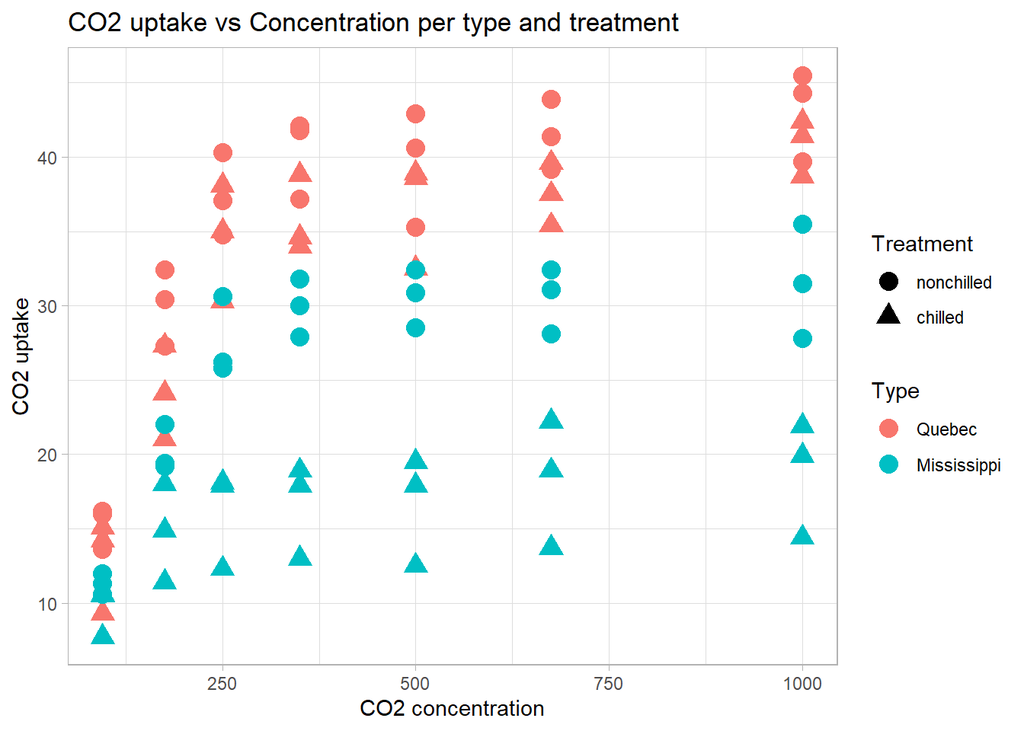

```r
ggplot(CO2, aes(x = conc, y = uptake, color = Type, shape = Treatment))+
  geom_point(size = 4) +
  theme_light() +
  labs(x = "CO2 concentration", y="CO2 uptake")+
  ggtitle("CO2 uptake vs Concentration per type and treatment")
```

# Task 8

1. Install the Tidybiology package
1. Extract summary statistics (mean, median and maximum) for the following variables from the ‘chromosome’ data: variations, protein coding genes, and miRNAs.

```r
data(chromosome)

sum_stats <- chromosome %>%
  select(variations, protein_codinggenes, mi_rna) %>%  #subset to the columns variations, protein_codinggenes, mi_rna
  pivot_longer(cols = c(variations, protein_codinggenes,mi_rna), names_to = "variable", values_to = "number") %>% #have all    variables listed in one column
  group_by(variable) %>%
  summarize(average = mean(number, na.rm = TRUE), med = median(number, na.rm = TRUE), maximum = max(number, na.rm = TRUE))

sum_stats
```

```
## # A tibble: 3 × 4
##   variable              average     med  maximum
##   <chr>                   <dbl>   <dbl>    <dbl>
## 1 mi_rna                   73.2      75      134
## 2 protein_codinggenes     850.      836     2058
## 3 variations          6484572.  6172346 12945965
```

2. How does the chromosome size distribute? Plot a graph that helps to visualize this by using ggplot2 package functions.

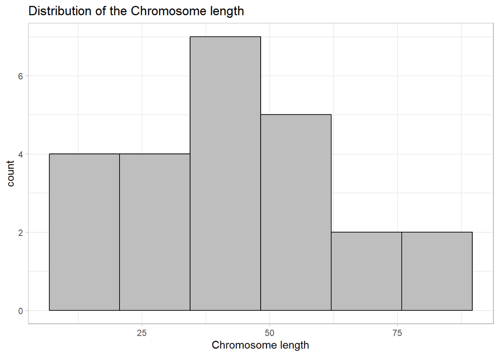

```r
ggplot(chromosome, (aes(x = length_mm))) +
  geom_histogram(bins = 6, fill = "grey", color = "black") +
  theme_light() +
  labs(x = "Chromosome length")+
  ggtitle("Distribution of the Chromosome length")
```

3. Does the number of protein coding genes or miRNAs correlate with the length of the chromosome? Make two separate plots to visualize these relationships.

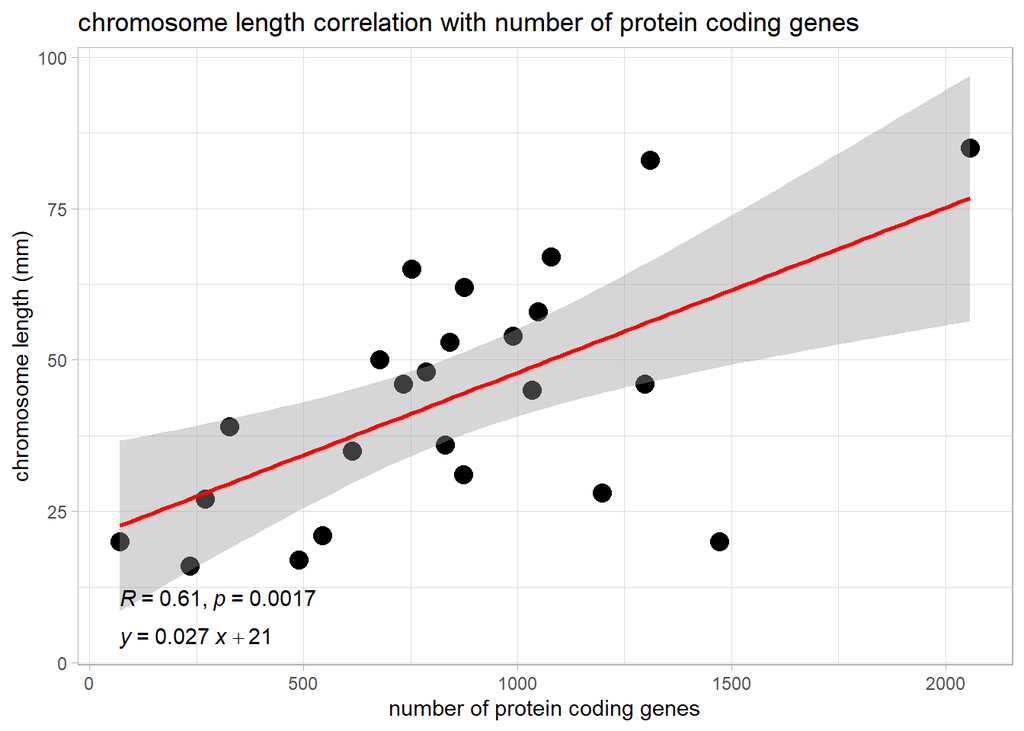

```r
ggplot(chromosome, aes(x = protein_codinggenes, y = length_mm))+
  geom_point(size = 4) +
  geom_smooth(method = "lm", color = "red") +
  theme_light() +
  labs(x = "number of protein coding genes", y="chromosome length (mm)")+
  ggtitle("chromosome length correlation with number of protein coding genes")+
  stat_cor(label.y = 10.4) +
  stat_regline_equation(label.y = 4.2)
```

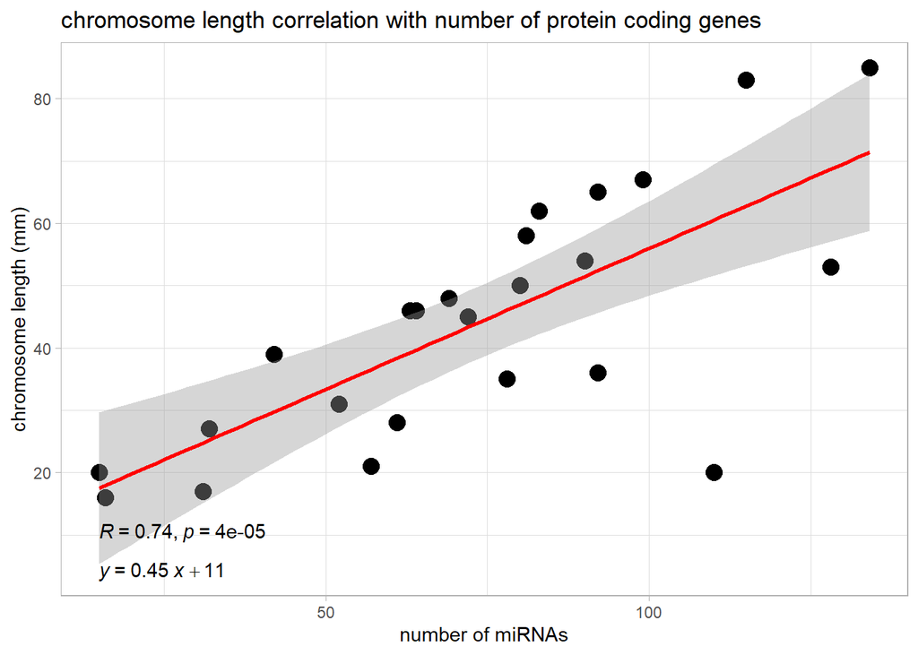

```
- both the number of protein coding genes and number of miRNAs are positively correlated with the chromosome length.           However number of miRNAs depict a stronger correlation with chromosome length than the number of protein coding genes
```

```r
ggplot(chromosome, aes(x = mi_rna, y = length_mm))+
  geom_point(size = 4) +
  geom_smooth(method = "lm", color = "red") +
  theme_light() +
  labs(x = "number of miRNAs", y="chromosome length (mm)")+
  ggtitle("chromosome length correlation with number of protein coding genes") +
  stat_cor(label.y = 10.4) +
  stat_regline_equation(label.y = 4.2)
```

4. Calculate the same summary statistics for the ‘proteins’ data variables length and mass. Create a meaningful visualization of the relationship between these two variables by utilizing the ggplot2 package functions.

```r
data(proteins)
protein_sum_stats <- proteins %>%
  select(length, mass) %>%
  pivot_longer(cols = c(length, mass), names_to = "characteristics", values_to = "value") %>%
  group_by(characteristics) %>%
  summarize(average = mean(value, na.rm = TRUE), med = median(value, na.rm = TRUE), maximum = max(value, na.rm = TRUE))

sum_stats
```

[output not shown]

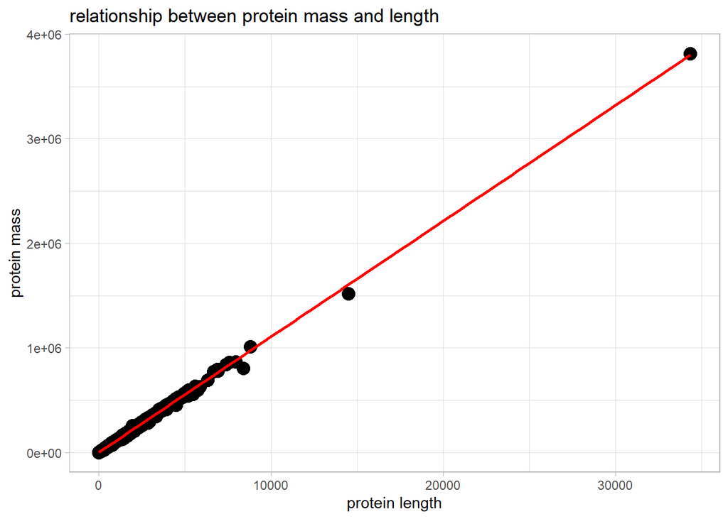

```r
ggplot(proteins, aes(x = length, y = mass))+
  geom_point(size = 4) +
  geom_smooth(method = "lm", color = "red") +
  theme_light() +
  labs(x = "protein length", y="protein mass")+
  ggtitle("relationship between protein mass and length")
```

- there is a very strong positive correlation between protein mass and length ```

## Overall conclusions

- when dealing with datasets, its best to familiarize oneself with what data they’re dealing with by using the help, view, head, structure functions
- functions sometimes work only on very specific classes or datatypes so the type and class functions are very helpful
- baseR plot functions are more straightforward but ggplot functions are better for customizing plots